# lab13

Patryk Tokarski

2022-06-11

1. Rozpatrzmy zbiory danych znajdujące się w plikach pod nazwami movies.csv i ratings.csv i zaimportujmy je do R Wczytajcie te zbiory danych do środowiska R jako ramki movies i ratings. Następnie połączcie te ramki w jedną movie_ratings względem zmiennej movieId
- Stwórzcie nową zmienną well_rated typu logicznego która przypisze wartość TRUE gdy mediana ocen użytkowników była większa lub równa 4.
- Stwórzcie nową zmienną year (typ całkowitoliczbowy) oraz title_no_year które zostaną utworzone na podstawie zmiennej title.
- Stwórzcie nową zmienną number_of_genres która pokaże liczbę gatunków przypisanych do każdego filmu.
- Stwórzcie nową zmienną typu logicznego xx_century, która pokaże wartość TRUE jeśli film jest z XX wieku i FALSE w pozostałych wypadkach.
- Stwórzcie nową zmienną typu logicznego homogenous która pokaże wartość TRUE wyłącznie w wypadku gdy film będzie miał przypisany dokładnie jeden gatunek. W przypadku wystąpienia wartości NA w dowolnej z nowych kolumn, omiń takie wiersze.

```r
movies <- read.csv("data/movies.csv")
ratings <- read.csv("data/ratings.csv")

movie_ratings <- merge(movies, ratings, by = "movieId")
head(movie_ratings)
```

```
##   movieId            title                                      genres userId
## 1       1 Toy Story (1995) Adventure|Animation|Children|Comedy|Fantasy      1
## 2       1 Toy Story (1995) Adventure|Animation|Children|Comedy|Fantasy    555
## 3       1 Toy Story (1995) Adventure|Animation|Children|Comedy|Fantasy    232
## 4       1 Toy Story (1995) Adventure|Animation|Children|Comedy|Fantasy    590
## 5       1 Toy Story (1995) Adventure|Animation|Children|Comedy|Fantasy    601
## 6       1 Toy Story (1995) Adventure|Animation|Children|Comedy|Fantasy    179
##   rating  timestamp
## 1    4.0  964982703
## 2    4.0  978746159
## 3    3.5 1076955621
## 4    4.0 1258420408
## 5    4.0 1521467801
## 6    4.0  852114051
```

```r
library(tidyverse)
movie_ratings <- movie_ratings %>%
  group_by(title) %>%
  mutate(well_rated=if_else(median(rating)>=4, T, F),
         title_no_year=str_extract_all(title, ".+(?= \\()"),
         year = str_extract_all(title, "(?<=\\()[0-9]{4}"),
         number_of_genres=str_count(genres,"[:alpha:]+"),
         xx_century=if_else(between(year, 1901,2000), T, F),
         homogenous=if_else(number_of_genres==1, T, F)
         )
movie_ratings <- na.omit(movie_ratings)
```

- Który film miał najwyższe średnie oceny, spośród tych które były oceniane co najmniej 30 razy? Jaka była ta średnia ocen?

```r
head(movie_ratings, n = 100) %>%
  count(title)
```

```
## # A tibble: 1 x 2
## # Groups:   title [1]
##   title                n
##   <chr>            <int>
## 1 Toy Story (1995)   100
```

```r
test <- movie_ratings %>%
  mutate(nr_of_voices = n())

test %>%
  filter(nr_of_voices>=30) %>%
  mutate(avg = mean(rating)) %>%
  ungroup() %>%
  arrange(desc(avg)) %>%
  distinct(title, avg) %>%
  head(1)
```

```
## # A tibble: 1 x 2
##   title                              avg
##   <chr>                            <dbl>
## 1 Shawshank Redemption, The (1994)  4.43
```

- Który z gatunków filmów był oceniany najlepiej? (w tym celu zakładamy, że np. Comedy i Com- edy|Romance to inne gatunki)

```r
movie_ratings2 <- merge(movies, ratings, by = "movieId")
movie_ratings2 <- movie_ratings2 %>%
  nest(data=c(userId:timestamp))

movie_ratings2 <- movie_ratings2 %>%
  rowwise() %>%
  mutate(avg_rating = mean(data$rating))

movie_ratings2 %>%
  group_by(genres) %>%
  summarise(mean = mean(avg_rating)) %>%
  arrange(desc(mean)) %>%
  head()
```

```
## # A tibble: 6 x 2
##   genres                                 mean
##   <chr>                                 <dbl>
## 1 Action|Comedy|Drama|Romance               5
## 2 Action|Crime|Drama|Sci-Fi                 5
## 3 Action|Horror|Mystery|Sci-Fi              5
## 4 Adventure|Comedy|Fantasy|Musical          5
## 5 Adventure|Drama|Fantasy|Horror|Sci-Fi     5
## 6 Adventure|Romance|Sci-Fi                  5
```

```r
movie_ratings2 %>%
  filter(genres=="Comedy|Romance") %>%
  filter(length(data$userId)>=75) %>%
  ungroup() %>%
  filter(avg_rating==min(avg_rating))
```

```
## # A tibble: 1 x 5
##   movieId title           genres         data               avg_rating
##     <int> <chr>           <chr>          <list>                  <dbl>
## 1      39 Clueless (1995) Comedy|Romance <tibble [104 x 3]>       3.29
```

2. Używając zbioru danych babynames z biblioteki o tej samej nazwie rozwiążcie poniższe problemy:
- Jakie było 5 najczęściej nadawanych imion chłopcom w 2017 roku oraz jaki procent wszystkich imion one stanowiły (procent w formacie np. 10.23)?

```r
library(babynames)
df <- babynames
df %>%
  filter(year==2017) %>%
  slice_max(n, n=5) %>%
  mutate(procent = format(prop*100, digits=2)) %>%
  select(name, procent)
```

[output not shown]

- Stwórz dwa wykresy kolumnowe 5 najczęściej nadawanych imion w 2017, jeden dla dziewczyn i drugi dla chłopców. Zmienną x mają być imiona, zaś y procent.

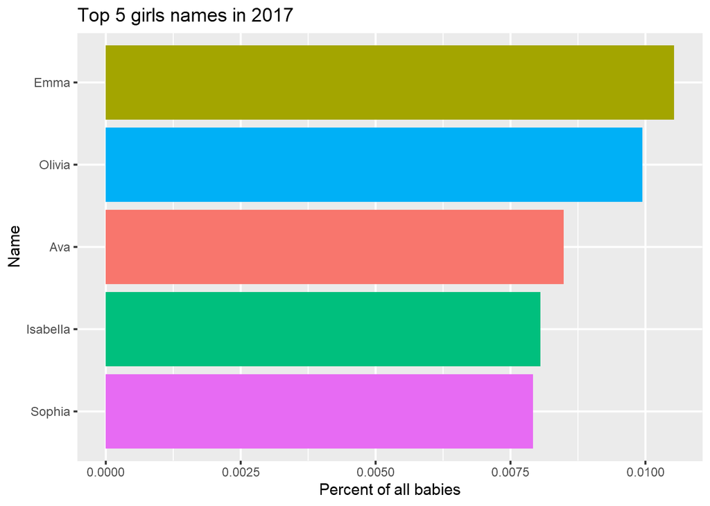

```r
girls <- df %>%
  filter(year==2017) %>%
  filter(sex=="F") %>%
  slice_max(n, n=5)

boys <- df %>%
  filter(year==2017) %>%
  filter(sex=="M") %>%
  slice_max(n, n=5)

girls %>%
  ggplot(aes(x=prop, y=fct_reorder(name, prop), fill=name))+
  geom_col(show.legend = F)+
  labs(y="Name", x="Percent of all babies",
       title="Top 5 girls names in 2017")
```

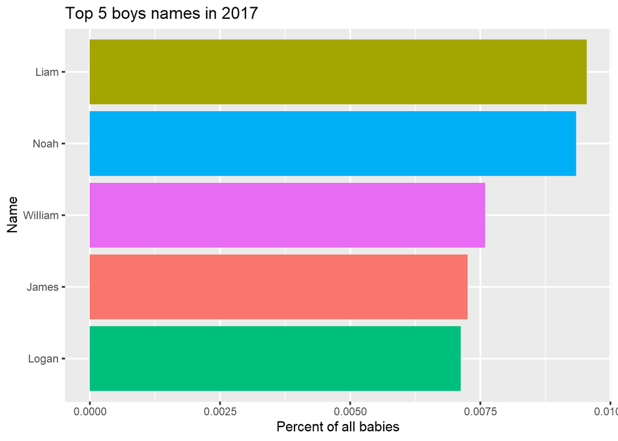

```r
boys %>%
  ggplot(aes(x=prop, y=fct_reorder(name, prop), fill=name))+
  geom_col(show.legend = F)+
  labs(y="Name", x="Percent of all babies",
       title="Top 5 boys names in 2017")
```

- Znajdź dzieci nazwane imieniem Ryan i policz jak wiele dzieci od 1880 roku zostało nazwanych tym imieniem z każdej z płci. Jaki procent wszystkich Ryanów stanowią dzieci danej płci

```r
df %>%
  filter(year>=1880,name=="Ryan") %>%
  group_by(sex) %>%
  summarise(sum(n))
```

```
## # A tibble: 2 x 2
##   sex   `sum(n)`
##   <chr>    <int>
## 1 F        22910
## 2 M       924877
```

```r
sum_of_ryans <- df %>%
  filter(year>=1880,name=="Ryan") %>%
  count(sum(n))
sum_of_ryans <- sum_of_ryans$`sum(n)`

df %>%
  filter(year>=1880,name=="Ryan") %>%
  group_by(sex) %>%
  summarise(percent = sum(n)/sum_of_ryans*100)
```

```
## # A tibble: 2 x 2
##   sex   percent
##   <chr>   <dbl>
## 1 F        2.42
## 2 M       97.6
```

- Stwórz wykres liniowy liczby nadań imiona Ryan dzieciom w czasie, pokolorowany względem płci dzieci.

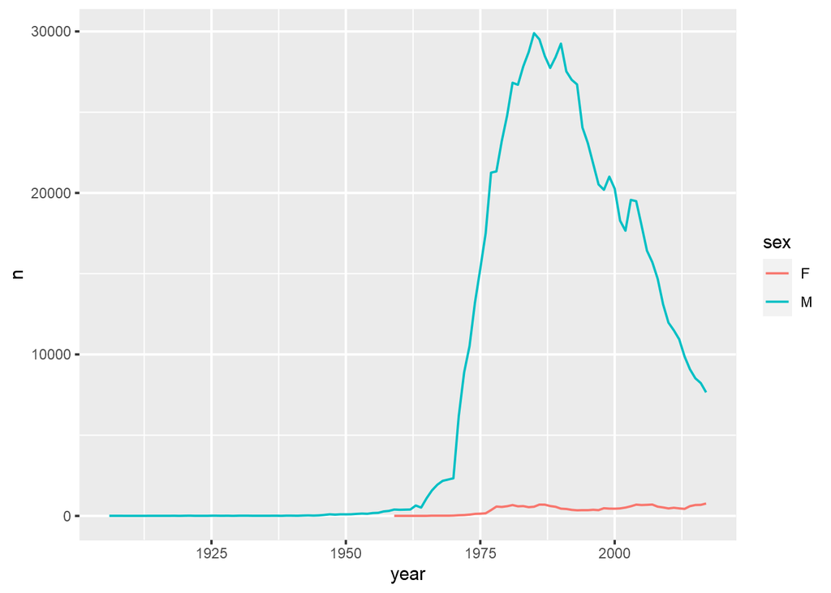

```r
ryan <- df %>%
  filter(name=="Ryan")
ryan %>% ggplot(aes(x=year,y=n,group=sex, color=sex))+
  geom_line()
```

```r
df %>%
  filter(sex=="M") %>%
  group_by(year) %>%
  slice_max(n) %>%
  select(year, name)
```

```
## # A tibble: 138 x 2
## # Groups:   year [138]
##     year name
##    <dbl> <chr>
##  1  1880 John
##  2  1881 John
##  3  1882 John
##  4  1883 John
##  5  1884 John
##  6  1885 John
##  7  1886 John
##  8  1887 John
##  9  1888 John
## 10  1889 John
## # ... with 128 more rows
```

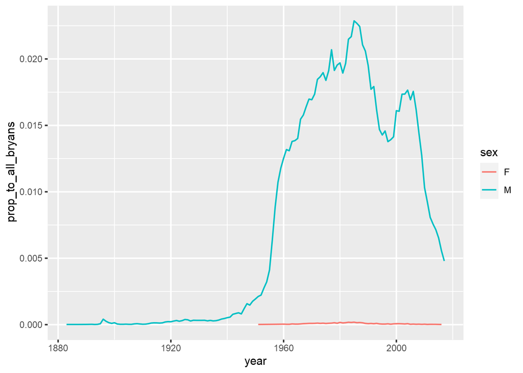

```r
df <- df %>%
  filter(name=="Bryan") %>%
  ungroup() %>%
  mutate(prop_to_all_bryans=n/sum(n))

df %>%  ggplot(aes(x=year, y=prop_to_all_bryans, color=sex))+
  geom_line()
```